# solution for q4

### Goal

The goal is to identify any interesting market segments that appear to stand out in NutrientH20’s social-media audience.

### Data Exploration

Some interesting finds from summary of the data:

1. There are 7882 followers in the dataset whose tweets have been categorized into 36 distinct categories.
2. The max number of spam tweets by any follower was 2. This meant that the spam filter was doing its job fairly well.

3. On the basis of relative frequency of tweet categories for every followers, we omitted the followers who had more than one-third of their tweets under uncategorized or adult. 26 followers were removed. 4. We will drop uncategorized, adult, chatter and spam columna as they don’t add value to cluster definition.

### Clustering

First will we perform K-means to find clusters of followers. Number of clusters will be chosen on the basis of elbow plot. The grid for k will be from 2 through 25.

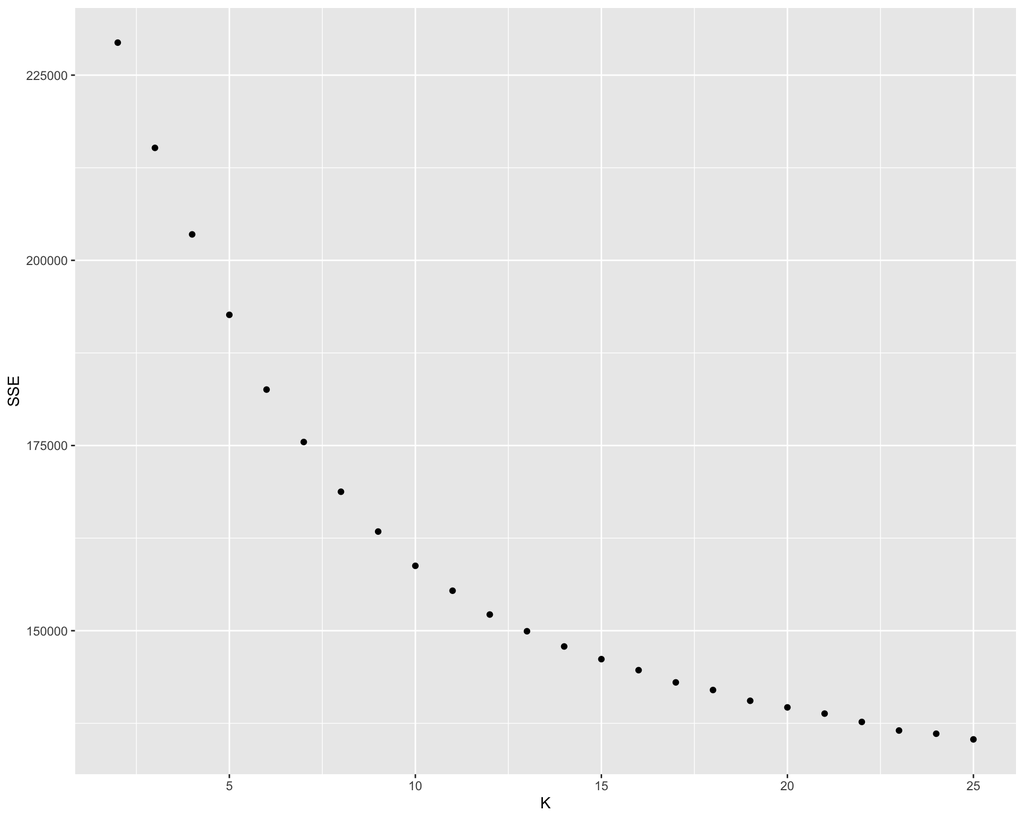

In the plot above, we can’t see a prominent elbow. We will now plot CH index plot to find value of K.

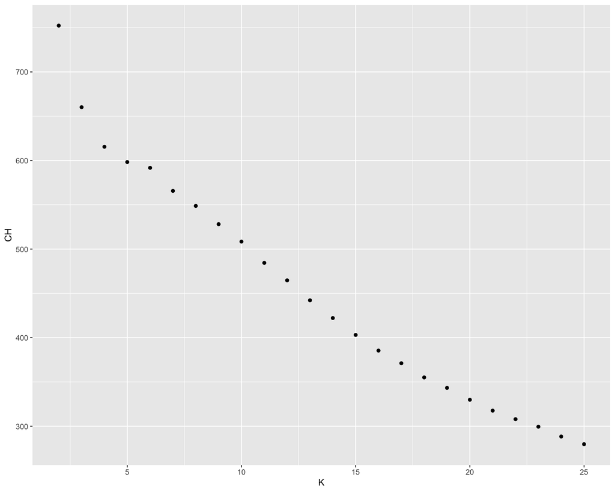

On the basis K vs CH index plot, we will choose k as 6.

```
## [1] 0.57242872 0.08783096 0.07179226 0.05766293 0.09699593 0.11328921
```

Next we will use K-means ++ initialization.

```
## [1] 0.57230143 0.05766293 0.08744908 0.09699593 0.11316191 0.07242872
```

K-means ++ is giving the same clusters sizes. So, we’ll stick with K-means result.

We now try Hierachical clustering to see if the results change.

```
##    1    2    3    4    5    6    7    8    9   10
## 7829    4    4    7    2    5    1    2    1    1
```

Heirachical clustering is not giving good result in this case as one of the cluster is huge with almost 99 percent of the followers.

### Cluster Analysis

We will use PCA to analyze the cluster. In the plot we see six clusters with position of the followers on the basis on principle component 1 and principle component 2.

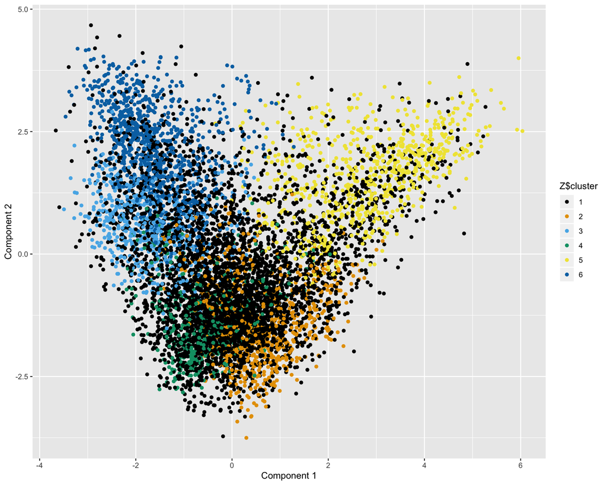

The order of loadings for principle component 1 is:

```
##  [1] "sports_fandom"    "religion"         "parenting"
##  [4] "food"             "school"           "family"
##  [7] "automotive"       "news"             "politics"
## [10] "crafts"           "computers"        "travel"
## [13] "tv_film"          "current_events"   "small_business"
## [16] "art"              "home_and_garden"  "business"
## [19] "eco"              "dating"           "music"
## [22] "sports_playing"   "shopping"         "college_uni"
## [25] "online_gaming"    "beauty"           "photo_sharing"
## [28] "outdoors"         "fashion"          "personal_fitness"
## [31] "health_nutrition" "cooking"
```

The order of loadings for principle component 2 is:

```
##  [1] "health_nutrition" "personal_fitness" "outdoors"
##  [4] "food"             "religion"         "parenting"
##  [7] "cooking"          "sports_fandom"    "school"
## [10] "beauty"           "fashion"          "family"
## [13] "dating"           "eco"              "crafts"
## [16] "home_and_garden"  "music"            "art"
## [19] "business"         "small_business"   "sports_playing"
## [22] "automotive"       "computers"        "news"
## [25] "current_events"   "shopping"         "online_gaming"
## [28] "photo_sharing"    "tv_film"          "college_uni"
## [31] "travel"           "politics"
```

We will also use biplot to define the clusters.

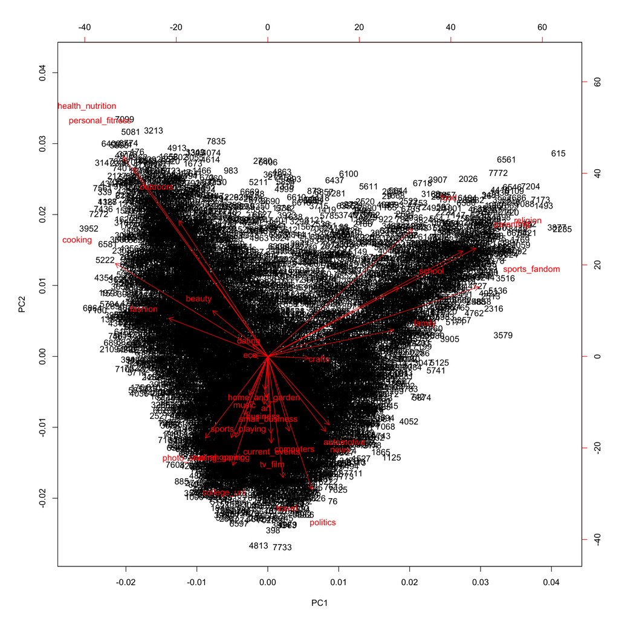

### Conclusion

On the basis of the biplot, principle component 1 and principle component 2 we can define our cluster of followers as:  
1. **Parents/Family oriented**: This cluster has followers who belong baby boomer or gen X category. They tweet a mostly about parenting, food, family, and religion.  
2. **Media Junkies**: This cluster has followers who talk about news, politics, business, and currenrt events. They like to talk about movies and television.  
3. **College Students**: This cluster has young lads who are in college and like talking about sports and online gaming. They also share photos and love to travel.  
4. **Artists**: This cluster has followers who are inclined towards music, crafts, and art.  
5. **Fitness Enthusiasts**: This cluster has followers with interests in health and nutrition, personal fitness, and talk about outdoor activities.  
6. **Beauty Bloggers**: This cluster has followers who are beauty conscious and talk about fashion and dating.